# Differential Expression on survival

2. запускаешь дифэкспрессию между хорошей и плохой выживаемостью, делаешь fgsea для статистики диф экспрессии для всех 10К генов

то есть 1 - 10к генов 2 - делим по выживаемости (times=2500) 3 - диффэкспрессия 4 - fgsea для статистики дифф экспрессии

```r
library(dplyr) # loads dplyr
library(survival) # core survival analysis functions
library(survminer) # recommended for visualizing survival curves
# Bioconductor packages
library(RTCGA)
library(RTCGA.clinical)
library(RTCGA.mRNA)
```

```r
library(DESeq2)
library(ggplot2)
library(vsn)
library(pheatmap)
library(ggrepel)
set.seed(1)
```

# Собираем данные

clinical data

```r
clinkLung <- survivalTCGA(LUSC.clinical,
                          extract.cols=c("admin.disease_code",
                                         "patient.gender",
                                         "patient.days_to_death",
                                         "patient.days_to_last_followup"))
dim(clinkLung)
```

```
[1] 494   7
```

```r
head(clinkLung)
```

|  | times | bcr_patient_barcode | patient.vital_status | admin.disease_code | patient.gender | patient.days_to_death | patient.days_to_last_followup |
| --- | --- | --- | --- | --- | --- | --- | --- |
| 39.63.0 | 371 | TCGA-18-3406 | 1 | lusc | male | 371 | NA |
| 39.63.0.1 | 136 | TCGA-18-3407 | 1 | lusc | male | 136 | NA |
| 39.63.0.2 | 2099 | TCGA-18-3408 | 0 | lusc | female | NA | 2099 |
| 39.63.0.3 | 2417 | TCGA-18-3409 | 0 | lusc | male | NA | 2417 |
| 39.63.0.4 | 146 | TCGA-18-3410 | 1 | lusc | male | 146 | NA |
| 39.63.0.5 | 1415 | TCGA-18-3411 | 0 | lusc | female | NA | 1415 |

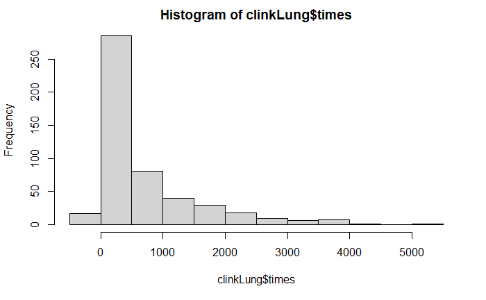

```r
hist(clinkLung$times)
```

RNA

```r
raw.counts <- readRDS("LUSC_counts.rds")

dim(raw.counts)
```

```
[1] 60660   553
```

```r
as.data.frame(raw.counts[1:5, 1:5])
```

|  | TCGA-18-4721-01A-01R-1443-07 | TCGA-77-7142-11A-01R-2045-07 | TCGA-34-5234-01A-01R-1635-07 | TCGA-21-1076-01A-01R-0692-07 | TCGA-77-A5G6-01A-11R-A27Q-07 |
| --- | --- | --- | --- | --- | --- |
| TSPAN6 | 1410 | 1054 | 5893 | 2569 | 4796 |
| TNMD | 0 | 5 | 3 | 4 | 2 |
| DPM1 | 1195 | 1444 | 4927 | 2408 | 1818 |
| SCYL3 | 472 | 718 | 955 | 737 | 756 |
| C1orf112 | 490 | 138 | 443 | 554 | 810 |

```r
dim(raw.counts)
```

```
[1] 60660   553
```

```r
counts.rna <- raw.counts[,!duplicated(substr(colnames(raw.counts), 1, 12))]
dim(counts.rna)
```

```
[1] 60660   501
```

```r
colnames(counts.rna) <- substr(colnames(counts.rna), 1, 12)
patients.rows <- Reduce(intersect,list(clinkLung$bcr_patient_barcode,colnames(counts.rna)))
counts.rna <- counts.rna %>%
  as.data.frame() %>%
  dplyr::select(order(colnames(counts.rna))) %>%
  dplyr::select(patients.rows) %>%
  dplyr::slice_max(rowSums(.), n = 10000)
dim(counts.rna)
```

```
[1] 10000   491
```

```r
counts.rna[1:5, 1:5]
```

|  | TCGA-18-3406 | TCGA-18-3407 | TCGA-18-3408 | TCGA-18-3409 | TCGA-18-3410 |
| --- | --- | --- | --- | --- | --- |
| IGHG1 | 395640 | 730110 | 114979 | 26227 | 386366 |
| MT.CO1 | 224940 | 511137 | 319772 | 289680 | 389660 |
| MT.ND4 | 165487 | 346901 | 243854 | 183117 | 177839 |
| IGKC | 1002310 | 655470 | 211789 | 25247 | 361165 |
| ACTB | 108895 | 246993 | 123910 | 306257 | 272101 |

concatenate rna + clinical data

good/bad survival using times

1 - dead (event), 0 - alive/censored 1 - bad survival, 0 - good

только для диффэкспрессии

```r
head(clinkLung)
```

|  | times | bcr_patient_barcode | patient.vital_status | admin.disease_code | patient.gender | patient.days_to_death | patient.days_to_last_followup |
| --- | --- | --- | --- | --- | --- | --- | --- |
| 39.63.0 | 371 | TCGA-18-3406 | 1 | lusc | male | 371 | NA |
| 39.63.0.1 | 136 | TCGA-18-3407 | 1 | lusc | male | 136 | NA |
| 39.63.0.2 | 2099 | TCGA-18-3408 | 0 | lusc | female | NA | 2099 |
| 39.63.0.3 | 2417 | TCGA-18-3409 | 0 | lusc | male | NA | 2417 |
| 39.63.0.4 | 146 | TCGA-18-3410 | 1 | lusc | male | 146 | NA |
| 39.63.0.5 | 1415 | TCGA-18-3411 | 0 | lusc | female | NA | 1415 |

```r
clinkLung_withSurvival <- clinkLung %>%
  mutate_at(c('patient.days_to_death', 'patient.days_to_last_followup'), as.numeric) %>%
  filter((patient.vital_status == 1 | patient.days_to_last_followup >= 2500)) %>%
  mutate(survival = ifelse((patient.vital_status == 1 & patient.days_to_death < 2500),"bad","good"))

rownames(clinkLung_withSurvival) <- clinkLung_withSurvival$bcr_patient_barcode

head(clinkLung_withSurvival)
```

|  | times | bcr_patient_barcode | patient.vital_status | admin.disease_code | patient.gender | patient.days_to_death | patient.days_to_last_followup | survival |
| --- | --- | --- | --- | --- | --- | --- | --- | --- |
| TCGA-18-3406 | 371 | TCGA-18-3406 | 1 | lusc | male | 371 | NA | bad |
| TCGA-18-3407 | 136 | TCGA-18-3407 | 1 | lusc | male | 136 | NA | bad |
| TCGA-18-3410 | 146 | TCGA-18-3410 | 1 | lusc | male | 146 | NA | bad |
| TCGA-18-3412 | 345 | TCGA-18-3412 | 1 | lusc | male | 345 | NA | bad |
| TCGA-18-3414 | 716 | TCGA-18-3414 | 1 | lusc | male | 716 | NA | bad |
| TCGA-18-4083 | 188 | TCGA-18-4083 | 1 | lusc | male | 188 | NA | bad |

```r
dim(clinkLung_withSurvival)
```

```
[1] 173   8
```

```r
clinik.and.rna <- as.data.frame(t(counts.rna))
clinik.and.rna$bcr_patient_barcode <- substr(rownames(clinik.and.rna), 1, 12)
clinik.and.rna <- clinik.and.rna %>%
  inner_join(clinkLung_withSurvival, by="bcr_patient_barcode")
clinik.and.rna[1:5, 1:5]
```

|  | IGHG1 | MT.CO1 | MT.ND4 | IGKC | ACTB |
| --- | --- | --- | --- | --- | --- |
| 1 | 395640 | 224940 | 165487 | 1002310 | 108895 |
| 2 | 730110 | 511137 | 346901 | 655470 | 246993 |
| 3 | 386366 | 389660 | 177839 | 361165 | 272101 |
| 4 | 99447 | 270529 | 179799 | 84886 | 339964 |
| 5 | 64396 | 367514 | 280858 | 57234 | 394496 |

```r
counts.rna.surv <- as.data.frame(counts.rna)
colnames(counts.rna.surv) <- substr(colnames(counts.rna.surv), 1, 12)
counts.rna.surv <- counts.rna.surv[, colnames(counts.rna.surv) %in% clinkLung_withSurvival$bcr_patient_barcode]
counts.rna.surv[1:5,1:5]
```

|  | TCGA-18-3406 | TCGA-18-3407 | TCGA-18-3410 | TCGA-18-3412 | TCGA-18-3414 |
| --- | --- | --- | --- | --- | --- |
| IGHG1 | 395640 | 730110 | 386366 | 99447 | 64396 |
| MT.CO1 | 224940 | 511137 | 389660 | 270529 | 367514 |
| MT.ND4 | 165487 | 346901 | 177839 | 179799 | 280858 |
| IGKC | 1002310 | 655470 | 361165 | 84886 | 57234 |
| ACTB | 108895 | 246993 | 272101 | 339964 | 394496 |

```r
pdata <- clinik.and.rna %>%
  arrange(bcr_patient_barcode) %>%
  dplyr::select(c("survival", "admin.disease_code", "patient.gender"))

pdata <- pdata[ order(row.names(pdata)), ]

head(pdata)
```

|  | survival | admin.disease_code | patient.gender |
| --- | --- | --- | --- |
| 1 | bad | lusc | male |
| 10 | good | lusc | female |
| 100 | bad | lusc | male |
| 101 | bad | lusc | male |
| 102 | bad | lusc | male |
| 103 | bad | lusc | male |

make sure there are no outliers

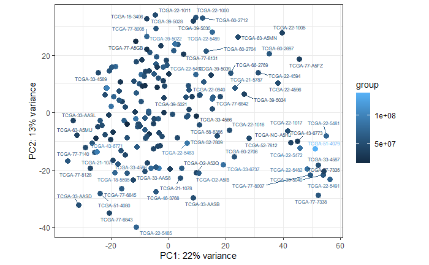

```r
ddsSimple <- DESeqDataSetFromMatrix(counts.rna.surv,
                              data.frame(strain=pdata$survival,
                                         libsize=colSums(counts.rna.surv),
                                         sampleName=colnames(counts.rna.surv),
                                         row.names=colnames(counts.rna.surv)), design=~1)
ddsSimple <- DESeq(ddsSimple)
vsdSimple <- varianceStabilizingTransformation(ddsSimple)
plotPCA(vsdSimple, "libsize") + geom_text_repel(aes(label=name), size=2) + theme_bw()
```

# Differencial expression

```r
dds <- DESeqDataSetFromMatrix(countData = counts.rna.surv,
                              colData = pdata,
                              design= ~ survival + patient.gender)
dds <- DESeq(dds)
```

```
-- replacing outliers and refitting for 226 genes
-- DESeq argument 'minReplicatesForReplace' = 7
-- original counts are preserved in counts(dds)
```

```r
resultsNames(dds)
```

```
[1] "Intercept"                     "survival_good_vs_bad"          "patient.gender_male_vs_female"
```

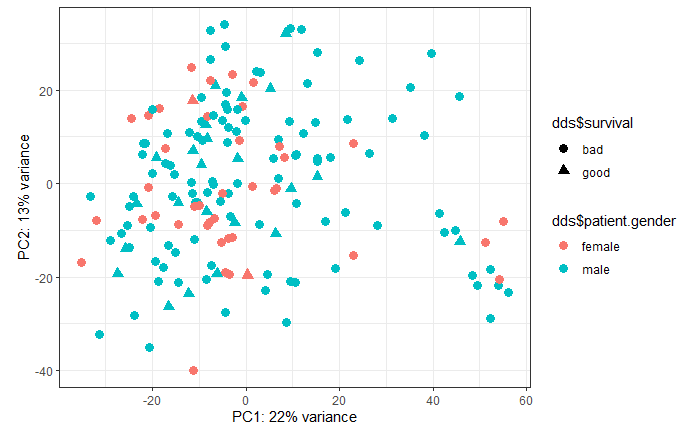

```r
vsd <- varianceStabilizingTransformation(dds)
plotPCA(vsd, "sizeFactor") + aes(color=dds$patient.gender, shape=dds$survival) + theme_bw()
```

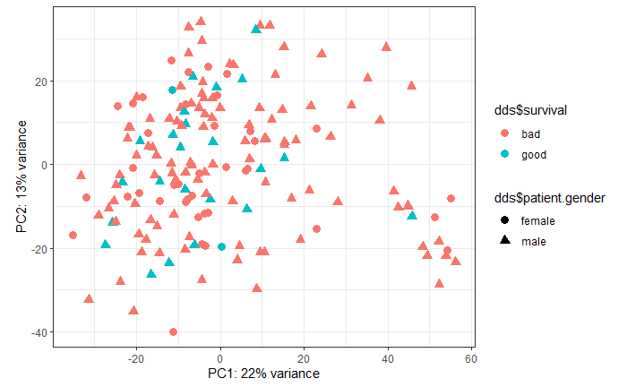

```r
plotPCA(vsd, "sizeFactor") + aes(color=dds$survival, shape=dds$patient.gender) + theme_bw()
```

## Volcano plot

```r
resultsNames(dds)
```

```
[1] "Intercept"                     "survival_good_vs_bad"          "patient.gender_male_vs_female"
```

```r
resShrinked <- lfcShrink(dds, coef="survival_good_vs_bad", type="apeglm")
```

```
using 'apeglm' for LFC shrinkage. If used in published research, please cite:
    Zhu, A., Ibrahim, J.G., Love, M.I. (2018) Heavy-tailed prior distributions for
    sequence count data: removing the noise and preserving large differences.
    Bioinformatics. https://doi.org/10.1093/bioinformatics/bty895
```

```r
resShrinked$Gene.symbol <- rownames(resShrinked)

head(resShrinked)
```

```
log2 fold change (MAP): survival good vs bad
Wald test p-value: survival good vs bad
DataFrame with 6 rows and 6 columns
        baseMean log2FoldChange     lfcSE    pvalue      padj Gene.symbol
       <numeric>      <numeric> <numeric> <numeric> <numeric> <character>
IGHG1     409445    0.002498271 0.0544047  0.723996  0.927654       IGHG1
MT.CO1    357174    0.006979443 0.0528072  0.661648  0.905463      MT.CO1
MT.ND4    344014   -0.000594243 0.0525366  0.967905  0.992702      MT.ND4
IGKC      377290   -0.002507251 0.0545752  0.656441  0.903426        IGKC
ACTB      310757   -0.002468006 0.0500269  0.903629  0.981778        ACTB
KRT5      273943   -0.001195817 0.0543580  0.861565  0.972137        KRT5
```

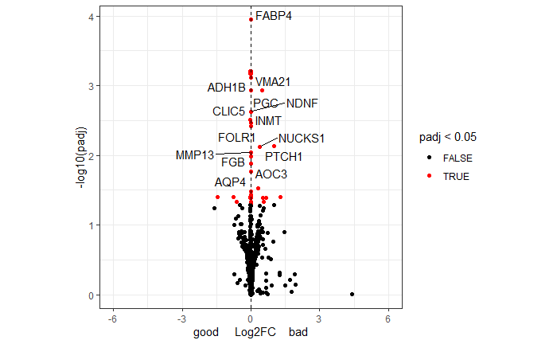

```r
resDF <- as.data.frame(resShrinked)
ggplot(resDF, aes(x=log2FoldChange, y=-log10(padj), color=padj < 0.05)) +
  geom_point() + theme_bw() + scale_color_manual(values=c("black", "red")) +
  geom_text_repel(data=resDF %>% dplyr::filter(padj < 0.05), aes(label=Gene.symbol), color="black") +
  xlim(c(-6, 6)) + xlab("good     Log2FC    bad") + geom_vline(xintercept = 0, lty=2) +
  theme(aspect.ratio = 1)
```

```r
counts.rna.amounts <- as.data.frame(t(counts.rna))
counts.rna.amounts$bcr_patient_barcode <- substr(rownames(counts.rna.amounts), 1, 12)
counts.rna.amounts <- counts.rna.amounts %>%
  inner_join(clinkLung, by="bcr_patient_barcode")
counts.rna.amounts[1:5, 1:5]
```

|  | IGHG1 | MT.CO1 | MT.ND4 | IGKC | ACTB |
| --- | --- | --- | --- | --- | --- |
| 1 | 395640 | 224940 | 165487 | 1002310 | 108895 |
| 2 | 730110 | 511137 | 346901 | 655470 | 246993 |
| 3 | 114979 | 319772 | 243854 | 211789 | 123910 |
| 4 | 26227 | 289680 | 183117 | 25247 | 306257 |
| 5 | 386366 | 389660 | 177839 | 361165 | 272101 |

```r
resDF %>% filter(padj < 0.05) %>% arrange(padj)
```

|  | baseMean | log2FoldChange | lfcSE | pvalue | padj | Gene.symbol |
| --- | --- | --- | --- | --- | --- | --- |
| FABP4 | 969.78069 | -0.013990427 | 0.05743193 | 1.126323e-08 | 0.0001126323 | FABP4 |
| SFTPA1 | 108733.92856 | -0.008829091 | 0.05574549 | 1.673517e-07 | 0.0006250991 | SFTPA1 |
| CLDN18 | 1589.57320 | -0.009678709 | 0.05592500 | 1.983561e-07 | 0.0006250991 | CLDN18 |
| PSCA | 422.32212 | -0.020772551 | 0.06086441 | 2.500396e-07 | 0.0006250991 | PSCA |
| SFTPC | 32434.53894 | -0.005452805 | 0.05506972 | 5.389744e-07 | 0.0006737180 | SFTPC |
| SUSD2 | 2431.53736 | -0.020593196 | 0.06034253 | 5.255866e-07 | 0.0006737180 | SUSD2 |
| CACNA2D2 | 1202.54216 | -0.012502420 | 0.05664365 | 4.342495e-07 | 0.0006737180 | CACNA2D2 |
| PEBP4 | 821.38925 | -0.013363868 | 0.05718826 | 3.610355e-07 | 0.0006737180 | PEBP4 |
| SFTPA2 | 133025.80962 | -0.009015854 | 0.05577822 | 6.834784e-07 | 0.0007594204 | SFTPA2 |
| VMA21 | 3945.93181 | 0.497379333 | 0.12033056 | 1.244241e-06 | 0.0011829598 | VMA21 |

[output cut: 32 more lines]

```r
mean(counts.rna.amounts$FABP4)
```

```
[1] 1271.943
```

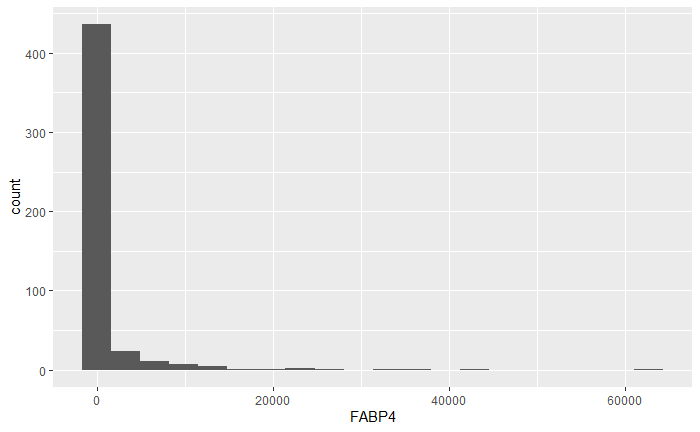

```r
ggplot(counts.rna.amounts, aes(FABP4)) + geom_histogram(bins=20)
```

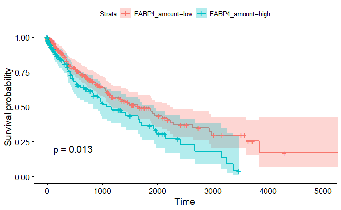

```r
counts.rna.amounts$FABP4_amount <- cut(counts.rna.amounts$FABP4,
                                           breaks=c(-Inf, 180, Inf),
                                           labels=c("low", "high"))

ggsurvplot(survfit(Surv(times, patient.vital_status)~FABP4_amount, data=counts.rna.amounts), pval=TRUE, conf.int=TRUE)
```

```r
mean(counts.rna.amounts$SFTPA1)
```

```
[1] 99617.24
```

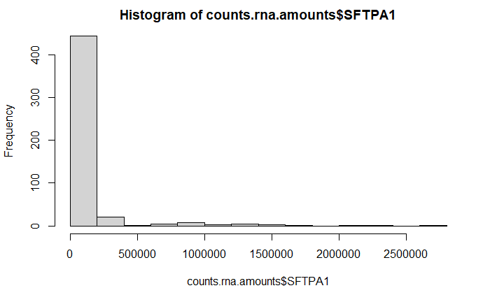

```r
hist(counts.rna.amounts$SFTPA1)
```

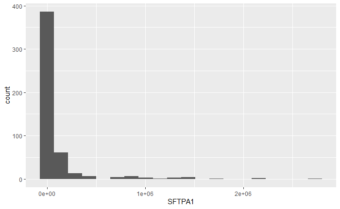

```r
ggplot(counts.rna.amounts, aes(SFTPA1)) + geom_histogram(bins=20)
```

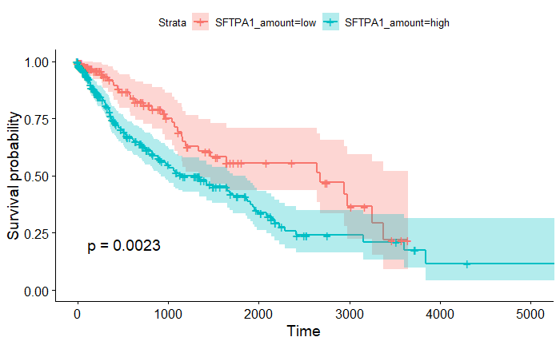

```r
counts.rna.amounts$SFTPA1_amount <- cut(counts.rna.amounts$SFTPA1,
                                           breaks=c(-Inf, 1500, Inf),
                                           labels=c("low", "high"))

ggsurvplot(survfit(Surv(times, patient.vital_status)~SFTPA1_amount, data=counts.rna.amounts), pval=TRUE, conf.int=TRUE)
```

```r
mean(counts.rna.amounts$CLDN18)
```

```
[1] 3907.868
```

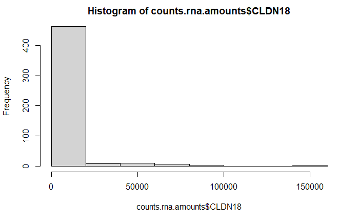

```r
hist(counts.rna.amounts$CLDN18)
```

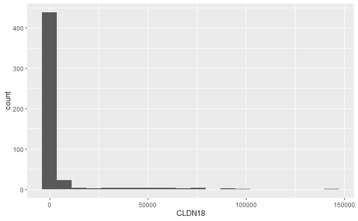

```r
ggplot(counts.rna.amounts, aes(CLDN18)) + geom_histogram(bins=20)
```

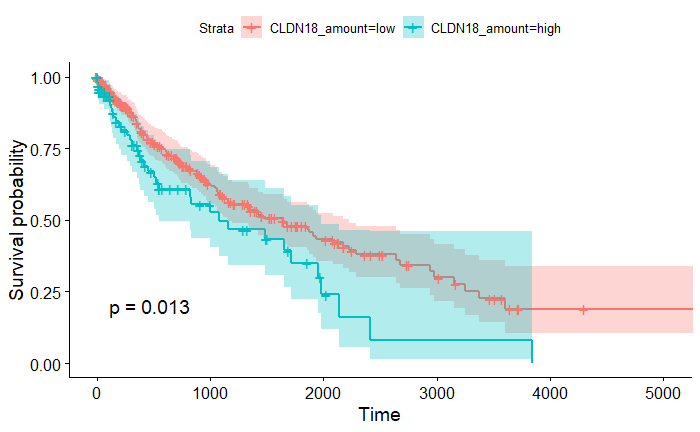

```r
counts.rna.amounts$CLDN18_amount <- cut(counts.rna.amounts$CLDN18,
                                           breaks=c(-Inf, 1100, Inf),
                                           labels=c("low", "high"))

ggsurvplot(survfit(Surv(times, patient.vital_status)~CLDN18_amount, data=counts.rna.amounts), pval=TRUE, conf.int=TRUE)
```

```r
mean(counts.rna.amounts$PSCA)
```

```
[1] 869.2729
```

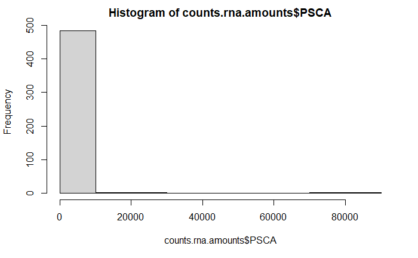

```r
hist(counts.rna.amounts$PSCA)
```

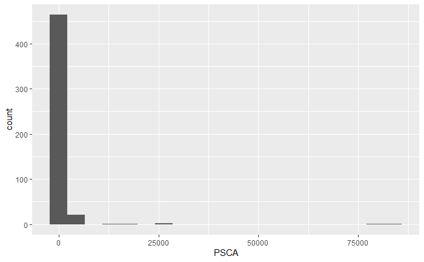

```r
ggplot(counts.rna.amounts, aes(PSCA)) + geom_histogram(bins=20)
```

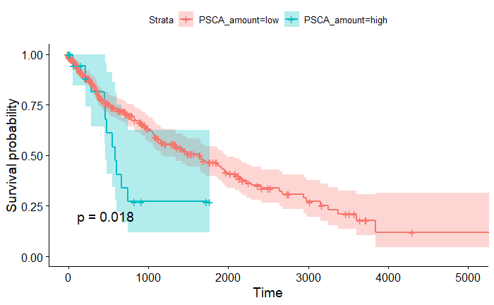

```r
counts.rna.amounts$PSCA_amount <- cut(counts.rna.amounts$PSCA,
                                           breaks=c(-Inf, 3000, Inf),
                                           labels=c("low", "high"))

ggsurvplot(survfit(Surv(times, patient.vital_status)~PSCA_amount, data=counts.rna.amounts), pval=TRUE, conf.int=TRUE)
```

check for just in case that we had both conditions

```r
resultsNames(dds)
```

```
[1] "Intercept"                     "survival_good_vs_bad"          "patient.gender_male_vs_female"
```

```r
resShrinked_lusc <- lfcShrink(dds, coef="patient.gender_male_vs_female", type="apeglm")
```

```
using 'apeglm' for LFC shrinkage. If used in published research, please cite:
    Zhu, A., Ibrahim, J.G., Love, M.I. (2018) Heavy-tailed prior distributions for
    sequence count data: removing the noise and preserving large differences.
    Bioinformatics. https://doi.org/10.1093/bioinformatics/bty895
```

```r
resShrinked_lusc$Gene.symbol <- rownames(resShrinked_lusc)

head(resShrinked_lusc)
```

```
log2 fold change (MAP): patient.gender male vs female
Wald test p-value: patient.gender male vs female
DataFrame with 6 rows and 6 columns
        baseMean log2FoldChange     lfcSE    pvalue      padj Gene.symbol
       <numeric>      <numeric> <numeric> <numeric> <numeric> <character>
IGHG1     409445    0.001302731 0.0257509  0.465268  0.901132       IGHG1
MT.CO1    357174    0.005055143 0.0261073  0.250537  0.829868      MT.CO1
MT.ND4    344014    0.001731823 0.0254956  0.681831  0.954023      MT.ND4
IGKC      377290    0.001663177 0.0258004  0.265076  0.836720        IGKC
ACTB      310757   -0.003263228 0.0252258  0.599677  0.937376        ACTB
KRT5      273943   -0.000820368 0.0257077  0.665053  0.952411        KRT5
```

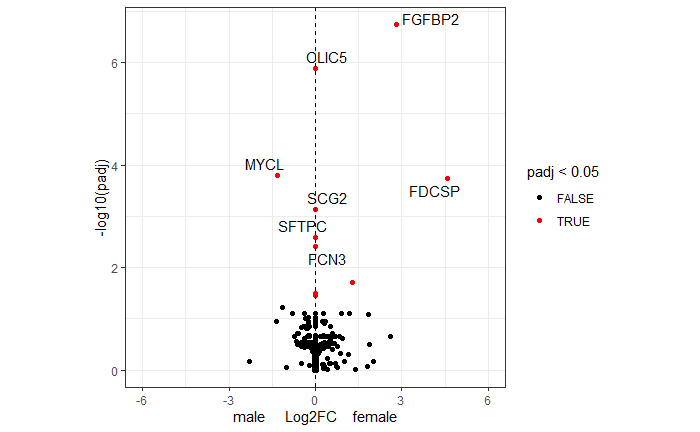

```r
resDF_lusc <- as.data.frame(resShrinked_lusc)
ggplot(resDF_lusc, aes(x=log2FoldChange, y=-log10(padj), color=padj < 0.05)) +
  geom_point() + theme_bw() + scale_color_manual(values=c("black", "red")) +
  geom_text_repel(data=resDF_lusc %>% dplyr::filter(padj < 1e-2), aes(label=Gene.symbol), color="black") +
  xlim(c(-6, 6)) + xlab("male     Log2FC    female") + geom_vline(xintercept = 0, lty=2) +
  theme(aspect.ratio = 1)
```

```r
upregulated <- resDF %>%
  filter(log2FoldChange > 0 & padj < 0.05) %>%
  arrange(desc(log2FoldChange))
writeLines(rownames(upregulated), "surv_upregulated.txt")
dim(upregulated)
```

```
[1] 10  6
```

```r
downregulated <- resDF %>%
  filter(log2FoldChange < 0 & padj < 0.05) %>%
  arrange(log2FoldChange)
writeLines(rownames(downregulated), "surv_downregulated.txt")
dim(downregulated)
```

```
[1] 32  6
```

## Pathway analysis

```r
library(fgsea)
load("keggSymbolHuman.rdata")
```

FGSEA

```r
#log2FoldChange < 0 = upregulated
stats <- resDF$log2FoldChange
names(stats) <- rownames(resDF)

fgseaResults.kegg <- fgseaMultilevel(keggSymbolHuman, stats, minSize = 15, maxSize = 500)
head(fgseaResults.kegg %>% arrange(padj))
```

| pathway | pval | padj | log2err | ES | NES | size | leadingEdge |
| --- | --- | --- | --- | --- | --- | --- | --- |
| AGE-RAGE signaling pathway in diabetic complications - Homo sapiens (human) | 0.011313152 | 0.4129637 | 0.3807304 | -0.5576225 | -1.702098 | 86 |  |
| Aldosterone-regulated sodium reabsorption - Homo sapiens (human) | 0.007161261 | 0.4129637 | 0.4070179 | -0.7346619 | -1.848415 | 22 |  |
| Fat digestion and absorption - Homo sapiens (human) | 0.009260500 | 0.4129637 | 0.3807304 | -0.8229246 | -1.938018 | 15 |  |
| Ferroptosis - Homo sapiens (human) | 0.012657892 | 0.4129637 | 0.3807304 | 0.7654410 | 1.811164 | 35 |  |
| Oxidative phosphorylation - Homo sapiens (human) | 0.003131502 | 0.4129637 | 0.4317077 | -0.5780728 | -1.737332 | 77 |  |
| Porphyrin and chlorophyll metabolism - Homo sapiens (human) | 0.012254707 | 0.4129637 | 0.3807304 | 0.8240047 | 1.843399 | 21 |  |

KEGG - not cool results, nothing statistically significant

msigdb hallmarks pathways enrichment

```r
library(msigdb)
```

```r
msigdb.hs = getMsigdb(org = 'hs',id = c("SYM", "EZID"))
# Downloading and integrating KEGG gene sets
msigdb.hs = appendKEGG(msigdb.hs)
length(msigdb.hs)
```

```
[1] 45349
```

Alexey suggested that I should use more human readable subsets like c2, c5 and h

```r
# You can select a child gene set according to the requirements
listCollections(msigdb.hs)
```

```
[1] "c1" "c2" "c3" "c4" "c5" "c6" "c7" "c8" "h"
```

```r
subset_msigdb = subsetCollection(msigdb.hs, c('h', 'c2', 'c5'))

#msigdb_ids <- geneIds(msigdb.hs)
msigdb_ids <- geneIds(subset_msigdb)
```

results here differs from those on https://www.gsea-msigdb.org/gsea/msigdb/human/compute_overlaps.jsp

```r
fgseaResults_msigdb <- fgseaMultilevel(msigdb_ids, stats, minSize = 15, maxSize = 500)
dim(fgseaResults_msigdb)
```

```
[1] 11682     8
```

```r
dim(fgseaResults_msigdb %>% filter(padj < 0.05))
```

```
[1] 5 8
```

```r
head(fgseaResults_msigdb %>% arrange(padj))
```

| pathway | pval | padj | log2err | ES | NES | size | leadingEdge |
| --- | --- | --- | --- | --- | --- | --- | --- |
| SABATES_COLORECTAL_ADENOMA_UP | 1.735755e-08 | 0.0002027709 | 0.7337620 | 0.9156134 | 2.363170 | 81 |  |
| NAKAYAMA_SOFT_TISSUE_TUMORS_PCA1_DN | 3.101456e-06 | 0.0168974410 | 0.6272567 | 0.9502532 | 2.272932 | 38 |  |
| REN_ALVEOLAR_RHABDOMYOSARCOMA_DN | 4.339353e-06 | 0.0168974410 | 0.6105269 | -0.4765396 | -1.819493 | 377 |  |
| HP_TIBIAL_BOWING | 7.775708e-06 | 0.0227089539 | 0.5933255 | 0.9687954 | 2.143062 | 22 |  |
| SARRIO_EPITHELIAL_MESENCHYMAL_TRANSITION_DN | 1.111522e-05 | 0.0259695961 | 0.5933255 | -0.6644970 | -2.220697 | 125 |  |
| HP_LARGE_FOR_GESTATIONAL_AGE | 3.922821e-05 | 0.0763773268 | 0.5573322 | 0.9272299 | 2.198805 | 33 |  |

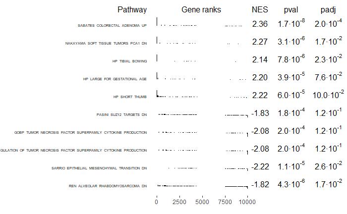

```r
topPathwaysUp <- fgseaResults_msigdb[ES > 0, ][head(order(padj), n=5), pathway]
topPathwaysDown <- fgseaResults_msigdb[ES < 0, ][head(order(padj), n=5), pathway]
topPathways <- c(topPathwaysUp, rev(topPathwaysDown))
plotGseaTable(msigdb_ids[topPathways], stats, fgseaResults_msigdb, gseaParam = 0.5,
              pathwayLabelStyle=list(size=5))
```

3. Для какого-то датасета разделить образцы с хорошей и плохой выживаемостью, сделать дифэкспрессию, и анализ пасвэев (msigdb hallmarks или gene ontology biological processes)
- После взять значимый, усреднить экспрессию его генов для каждого пациента, и сделать cox regression
- Сгенерировать 1000 случайных наборов генов такого же размера и проверить, что у них cox regression likelihood будет хуже чем у исходного пасвэя
- Аналогично сделать для какого-то левого пасвэя, у которого не было значимости
3. есть пасвэи, для каждого пасвэя усреднить экспрессиию и сделать cox regression на получившихся “профилях” для пасвэев

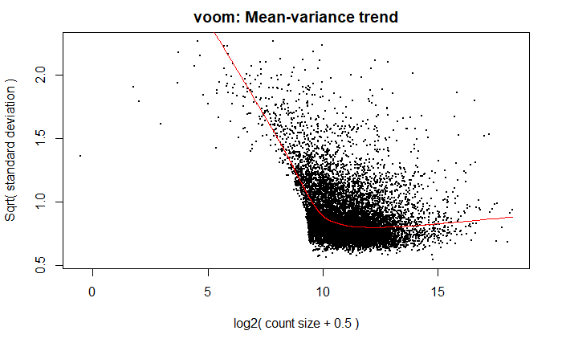

```r
counts.rna.voom <- limma::voom(counts.rna, plot = T)
```

```r
head(as.data.frame(counts.rna.voom$targets))
```

|  | lib.size |
| --- | --- |
| TCGA-18-3406 | 39262239 |
| TCGA-18-3407 | 47418925 |
| TCGA-18-3408 | 35923849 |
| TCGA-18-3409 | 41493643 |
| TCGA-18-3410 | 52017007 |
| TCGA-18-3411 | 56749606 |

```r
head(as.data.frame(counts.rna.voom$weights))
```

|  | V1 | V2 | V3 | V4 | V5 | V6 | V7 | V8 | V9 | V10 | V11 | V12 | V13 | V14 | V15 | V16 | V17 | V18 | V19 | V20 | V21 | V22 | V23 | V24 | V25 | V26 | V27 | V28 | V29 | … |
| --- | --- | --- | --- | --- | --- | --- | --- | --- | --- | --- | --- | --- | --- | --- | --- | --- | --- | --- | --- | --- | --- | --- | --- | --- | --- | --- | --- | --- | --- | --- |
| 1 | 1.845522 | 1.806419 | 1.864056 | 1.834052 | 1.787422 | 1.769625 | 1.761543 | 1.784337 | 1.849294 | 1.850143 | 1.965339 | 1.847253 | 1.827113 | 1.795242 | 1.774026 | 1.977077 | 1.759312 | 1.717882 | 1.820720 | 1.809665 | 1.763941 | 1.764537 | 1.773016 | 1.770331 | 1.788748 | 1.793869 | 1.783753 | 1.689969 | 1.775136 | … |
| 2 | 1.706239 | 1.669300 | 1.723918 | 1.695346 | 1.663180 | 1.663180 | 1.663180 | 1.663180 | 1.709822 | 1.710627 | 1.821745 | 1.707883 | 1.688807 | 1.663180 | 1.663180 | 1.833190 | 1.663180 | 1.663180 | 1.682783 | 1.672360 | 1.663180 | 1.663180 | 1.663180 | 1.663180 | 1.663180 | 1.663180 | 1.663180 | 1.663180 | 1.663180 | … |
| 3 | 1.716815 | 1.679648 | 1.734549 | 1.705839 | 1.663180 | 1.663180 | 1.663180 | 1.663180 | 1.720426 | 1.721238 | 1.832818 | 1.718472 | 1.699248 | 1.669073 | 1.663180 | 1.844232 | 1.663180 | 1.663180 | 1.693206 | 1.682731 | 1.663180 | 1.663180 | 1.663180 | 1.663180 | 1.663180 | 1.667781 | 1.663180 | 1.663180 | 1.663180 | … |
| 4 | 1.877256 | 1.837868 | 1.895901 | 1.865678 | 1.818660 | 1.800742 | 1.792550 | 1.815538 | 1.881063 | 1.881919 | 1.997754 | 1.879003 | 1.858726 | 1.826574 | 1.805164 | 2.009589 | 1.790286 | 1.748326 | 1.852302 | 1.841144 | 1.794983 | 1.795587 | 1.804148 | 1.801451 | 1.820002 | 1.825185 | 1.814947 | 1.719996 | 1.806278 | … |
| 5 | 1.731401 | 1.693955 | 1.749283 | 1.720381 | 1.675866 | 1.663180 | 1.663180 | 1.672934 | 1.735022 | 1.735837 | 1.848001 | 1.733063 | 1.713720 | 1.683301 | 1.663189 | 1.859495 | 1.663180 | 1.663180 | 1.707613 | 1.697055 | 1.663180 | 1.663180 | 1.663180 | 1.663180 | 1.677127 | 1.681996 | 1.672378 | 1.663180 | 1.664236 | … |
| 6 | 1.936964 | 1.897191 | 1.955821 | 1.925305 | 1.877768 | 1.859564 | 1.851252 | 1.874596 | 1.940786 | 1.941646 | 2.059341 | 1.938718 | 1.918232 | 1.885764 | 1.864057 | 2.071549 | 1.848947 | 1.806226 | 1.911745 | 1.900522 | 1.853730 | 1.854345 | 1.863026 | 1.860285 | 1.879130 | 1.884369 | 1.873996 | 1.777249 | 1.865189 | … |

```r
head(as.data.frame(counts.rna.voom$design))
```

|  | GrandMean |
| --- | --- |
| TCGA-18-3406 | 1 |
| TCGA-18-3407 | 1 |
| TCGA-18-3408 | 1 |
| TCGA-18-3409 | 1 |
| TCGA-18-3410 | 1 |
| TCGA-18-3411 | 1 |

```r
head(as.data.frame(counts.rna.voom$E))
```

|  | TCGA-18-3406 | TCGA-18-3407 | TCGA-18-3408 | TCGA-18-3409 | TCGA-18-3410 | TCGA-18-3411 | TCGA-18-3412 | TCGA-18-3414 | TCGA-18-3415 | TCGA-18-3416 | TCGA-18-3417 | TCGA-18-3419 | TCGA-18-3421 | TCGA-18-4083 | TCGA-18-4086 | TCGA-18-4721 | TCGA-18-5592 | TCGA-18-5595 | TCGA-21-1070 | TCGA-21-1071 | TCGA-21-1072 | TCGA-21-1075 | TCGA-21-1076 | TCGA-21-1077 | TCGA-21-1078 | TCGA-21-1079 | TCGA-21-1080 | TCGA-21-1081 | TCGA-21-1082 | … |
| --- | --- | --- | --- | --- | --- | --- | --- | --- | --- | --- | --- | --- | --- | --- | --- | --- | --- | --- | --- | --- | --- | --- | --- | --- | --- | --- | --- | --- | --- | --- |
| IGHG1 | 13.29876 | 13.91036 | 11.64415 | 9.303974 | 12.85870 | 12.60410 | 10.71766 | 10.25201 | 12.74488 | 13.19953 | 12.90902 | 14.36783 | 8.605030 | 13.35987 | 13.73956 | 14.23722 | 12.67305 | 8.164907 | 13.84608 | 12.49980 | 10.46673 | 9.185241 | 13.15426 | 12.71514 | 7.471532 | 11.58031 | 10.62925 | 12.50909 | 14.26489 | … |
| MT.CO1 | 12.48411 | 13.39596 | 13.11982 | 12.769285 | 12.87095 | 11.88361 | 12.16144 | 12.76475 | 11.70252 | 12.79899 | 12.37760 | 11.36353 | 11.912075 | 13.60237 | 12.59210 | 12.19772 | 12.75330 | 11.339096 | 13.69673 | 12.67553 | 12.64197 | 12.184493 | 13.05845 | 12.36010 | 13.118811 | 11.79528 | 12.20863 | 13.78492 | 13.82614 | … |
| MT.ND4 | 12.04129 | 12.83678 | 12.72879 | 12.107592 | 11.73930 | 11.58421 | 11.57204 | 12.37679 | 11.20678 | 12.80551 | 12.54198 | 12.06054 | 12.122491 | 13.72707 | 12.33577 | 12.27145 | 12.90058 | 11.525221 | 13.35847 | 12.71581 | 12.31933 | 12.238241 | 12.88923 | 12.43956 | 12.510827 | 12.00393 | 12.36897 | 14.02544 | 14.13991 | … |
| IGKC | 14.63983 | 13.75478 | 12.52540 | 9.249034 | 12.76139 | 12.34871 | 10.48926 | 10.08191 | 12.52887 | 13.05486 | 12.86998 | 13.85861 | 9.051239 | 13.02783 | 13.78796 | 13.92521 | 11.88806 | 8.578771 | 13.61905 | 11.93737 | 10.61076 | 9.185028 | 13.08110 | 13.68214 | 8.651237 | 10.67427 | 10.25304 | 11.25986 | 14.00327 | … |
| ACTB | 11.43751 | 12.34672 | 11.75207 | 12.849567 | 12.35287 | 12.53435 | 12.49103 | 12.86696 | 12.41349 | 12.15244 | 13.13860 | 11.40019 | 12.322501 | 11.93262 | 12.42648 | 12.17368 | 11.69327 | 12.334004 | 12.93509 | 12.18368 | 12.33806 | 12.221668 | 12.59216 | 12.14760 | 11.911874 | 13.28037 | 11.71167 | 12.90437 | 12.51441 | … |
| KRT5 | 13.36410 | 12.13700 | 10.73063 | 11.637135 | 13.09369 | 11.56566 | 14.11785 | 12.60643 | 13.13429 | 14.21319 | 12.94784 | 12.71679 | 11.712598 | 12.49563 | 12.53345 | 11.87799 | 13.87264 | 14.292832 | 12.67993 | 11.49744 | 12.87697 | 11.307005 | 11.03283 | 11.88104 | 4.906020 | 13.28068 | 13.31723 | 12.04725 | 12.85798 | … |

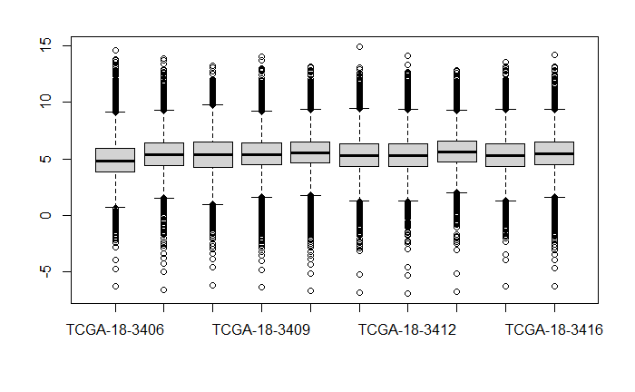

```r
boxplot(as.data.frame(counts.rna.voom[, 1:10]$E))
```

```r
clinik.and.rna.pathways <- as.data.frame(t(counts.rna.voom$E))
clinik.and.rna.pathways$bcr_patient_barcode <- substr(rownames(clinik.and.rna.pathways), 1, 12)
clinik.and.rna.pathways <- clinik.and.rna.pathways %>%
  inner_join(clinkLung, by="bcr_patient_barcode")
dim(clinik.and.rna.pathways)
```

```
[1]   491 10007
```

```r
head(clinik.and.rna.pathways)
```

|  | IGHG1 | MT.CO1 | MT.ND4 | IGKC | ACTB | KRT5 | EEF1A1 | FTL | MT.RNR2 | ACTG1 | MT.CO3 | COL1A1 | MT.CO2 | KRT6A | COL3A1 | IGHA1 | B2M | MT.CYB | GAPDH | KRT17 | FN1 | COL1A2 | MT.ND2 | SFTPB | SFTPA2 | CD74 | ENO1 | EEF2 | PKM | … |
| --- | --- | --- | --- | --- | --- | --- | --- | --- | --- | --- | --- | --- | --- | --- | --- | --- | --- | --- | --- | --- | --- | --- | --- | --- | --- | --- | --- | --- | --- | --- |
| 1 | 13.298760 | 12.48411 | 12.04129 | 14.639827 | 11.43751 | 13.36410 | 13.75391 | 11.41608 | 11.80147 | 11.66211 | 11.88647 | 10.240250 | 11.58110 | 13.739845 | 10.870317 | 11.466980 | 12.77227 | 11.34631 | 11.64144 | 13.028286 | 10.14740 | 10.086929 | 11.114826 | 8.530733 | 5.917730 | 11.18451 | 11.39356 | 10.41975 | 10.22320 | … |
| 2 | 13.910364 | 13.39596 | 12.83678 | 13.754780 | 12.34672 | 12.13700 | 12.59656 | 11.31204 | 12.85926 | 12.24997 | 12.30499 | 12.712308 | 12.14350 | 11.743892 | 12.907846 | 12.445907 | 11.54666 | 11.34465 | 11.00795 | 12.346506 | 11.60009 | 12.090245 | 10.824129 | 11.677628 | 10.396577 | 10.13723 | 10.98941 | 12.33239 | 10.72091 | … |
| 3 | 11.644147 | 13.11982 | 12.72879 | 12.525401 | 11.75207 | 10.73063 | 13.25249 | 12.05842 | 12.54211 | 10.80814 | 11.89305 | 7.655402 | 11.95836 | 11.367091 | 9.323887 | 7.756550 | 11.80540 | 11.64877 | 11.15716 | 8.964545 | 10.10855 | 9.004033 | 11.041583 | 10.558030 | 11.748980 | 10.98875 | 10.30311 | 8.89277 | 10.97453 | … |
| 4 | 9.303974 | 12.76928 | 12.10759 | 9.249034 | 12.84957 | 11.63713 | 13.01249 | 12.76653 | 12.45447 | 11.98189 | 11.69464 | 14.018393 | 11.30935 | 5.146291 | 13.729986 | 8.821515 | 11.72997 | 11.12423 | 11.07627 | 11.910570 | 12.92827 | 13.717434 | 10.749939 | 10.759578 | 7.823089 | 11.54023 | 11.64217 | 10.83217 | 10.86576 | … |
| 5 | 12.858699 | 12.87095 | 11.73930 | 12.761389 | 12.35287 | 13.09369 | 13.20358 | 11.30135 | 11.50014 | 11.58090 | 11.47144 | 10.207845 | 10.72356 | 7.793006 | 10.635185 | 11.226942 | 12.65529 | 10.67283 | 11.27062 | 7.424260 | 10.23486 | 9.809775 | 10.507847 | 7.781581 | 7.666435 | 12.00306 | 11.16825 | 11.90935 | 11.77868 | … |
| 6 | 12.604104 | 11.88361 | 11.58421 | 12.348711 | 12.53435 | 11.56566 | 12.90446 | 14.95445 | 11.97054 | 12.27135 | 11.32805 | 10.523218 | 10.97978 | 11.267060 | 10.818775 | 8.679428 | 11.19791 | 10.17319 | 11.06884 | 12.016251 | 10.11775 | 10.319801 | 9.726326 | 4.381086 | 5.238541 | 10.73320 | 10.93362 | 10.76975 | 11.52044 | … |

```r
for(pathway in topPathways) {
  genes <- intersect(unique(unlist(msigdb_ids[pathway])), colnames(clinik.and.rna.pathways))

  clinik.and.rna.pathways[pathway] <- rowMeans(clinik.and.rna.pathways[, genes])
}

pathways_to_test <- topPathways

head(clinik.and.rna.pathways[pathways_to_test])
```

|  | SABATES_COLORECTAL_ADENOMA_UP | NAKAYAMA_SOFT_TISSUE_TUMORS_PCA1_DN | HP_TIBIAL_BOWING | HP_LARGE_FOR_GESTATIONAL_AGE | HP_SHORT_THUMB | PASINI_SUZ12_TARGETS_DN | GOBP_TUMOR_NECROSIS_FACTOR_SUPERFAMILY_CYTOKINE_PRODUCTION | GOBP_REGULATION_OF_TUMOR_NECROSIS_FACTOR_SUPERFAMILY_CYTOKINE_PRODUCTION | SARRIO_EPITHELIAL_MESENCHYMAL_TRANSITION_DN | REN_ALVEOLAR_RHABDOMYOSARCOMA_DN |
| --- | --- | --- | --- | --- | --- | --- | --- | --- | --- | --- |
| 1 | 4.915433 | 3.276535 | 4.933092 | 4.158196 | 5.521139 | 5.968068 | 5.306443 | 5.306443 | 6.774524 | 6.192734 |
| 2 | 5.329589 | 4.151677 | 5.820135 | 5.183104 | 6.097636 | 6.494224 | 5.792138 | 5.792138 | 7.000006 | 6.621938 |
| 3 | 4.795905 | 3.881636 | 4.845828 | 5.072419 | 5.879089 | 6.287392 | 5.088047 | 5.088047 | 6.400270 | 6.431771 |
| 4 | 4.470762 | 4.937148 | 6.792291 | 5.162730 | 6.280424 | 6.871757 | 5.669322 | 5.669322 | 6.225318 | 6.918833 |
| 5 | 4.084471 | 3.961220 | 5.507405 | 5.156228 | 6.385293 | 6.024002 | 5.889108 | 5.889108 | 6.313704 | 6.275023 |
| 6 | 4.934940 | 4.197341 | 5.180769 | 4.814486 | 5.973687 | 6.187963 | 5.370776 | 5.370776 | 6.341611 | 6.467999 |

```r
#clinik.and.rna[, test_pathway[, 1][test_pathway[, 1] %in% colnames(clinik.and.rna)]]
#rowMeans(clinik.and.rna[, test_pathway[, 1][test_pathway[, 1] %in% colnames(clinik.and.rna)]])
```

```r
Survfun <- function(gene) as.formula(paste("Surv(times,patient.vital_status)",gene,sep="~"))

survival.coxph.pathways <-
  sapply(pathways_to_test, function(gene) summary(coxph(Survfun(gene), data=clinik.and.rna.pathways)))
```

```r
survival.coxph.pathways <- survival.coxph.pathways %>% t() %>% as.data.frame() %>% dplyr::select(coefficients)
survival.coxph.pathways[1,]
```

```
$SABATES_COLORECTAL_ADENOMA_UP
                                    coef exp(coef)  se(coef)         z  Pr(>|z|)
SABATES_COLORECTAL_ADENOMA_UP 0.01691747  1.017061 0.1455828 0.1162052 0.9074899
```

```r
coxph(Surv(times,patient.vital_status)~SABATES_COLORECTAL_ADENOMA_UP, data=clinik.and.rna.pathways)
```

```
Call:
coxph(formula = Surv(times, patient.vital_status) ~ SABATES_COLORECTAL_ADENOMA_UP,
    data = clinik.and.rna.pathways)

                                 coef exp(coef) se(coef)     z     p
SABATES_COLORECTAL_ADENOMA_UP 0.01692   1.01706  0.14558 0.116 0.907

Likelihood ratio test=0.01  on 1 df, p=0.9074
n= 491, number of events= 155
```

```r
survival.coxph.pathways.rownames <- rownames(survival.coxph.pathways)

survival.coxph.pathways <- as.data.frame(matrix(unlist(survival.coxph.pathways),ncol=5,byrow=TRUE))
rownames(survival.coxph.pathways) <- survival.coxph.pathways.rownames
colnames(survival.coxph.pathways) <- c("coef", "HR", "se", "z", "Pval")

survival.coxph.pathways %>% arrange(Pval)
```

|  | coef | HR | se | z | Pval |
| --- | --- | --- | --- | --- | --- |
| GOBP_TUMOR_NECROSIS_FACTOR_SUPERFAMILY_CYTOKINE_PRODUCTION | 0.43537139 | 1.5455370 | 0.1878979 | 2.3170632 | 0.02050029 |
| GOBP_REGULATION_OF_TUMOR_NECROSIS_FACTOR_SUPERFAMILY_CYTOKINE_PRODUCTION | 0.43537139 | 1.5455370 | 0.1878979 | 2.3170632 | 0.02050029 |
| PASINI_SUZ12_TARGETS_DN | 0.43802843 | 1.5496490 | 0.2667151 | 1.6423082 | 0.10052615 |
| REN_ALVEOLAR_RHABDOMYOSARCOMA_DN | 0.41214661 | 1.5100558 | 0.2936398 | 1.4035786 | 0.16044436 |
| SARRIO_EPITHELIAL_MESENCHYMAL_TRANSITION_DN | 0.30554391 | 1.3573631 | 0.2563945 | 1.1916945 | 0.23338105 |
| HP_SHORT_THUMB | -0.23031981 | 0.7942795 | 0.3360501 | -0.6853735 | 0.49310829 |
| HP_LARGE_FOR_GESTATIONAL_AGE | 0.17369288 | 1.1896901 | 0.2657499 | 0.6535954 | 0.51337253 |
| HP_TIBIAL_BOWING | 0.07582105 | 1.0787695 | 0.1207618 | 0.6278561 | 0.53009818 |
| NAKAYAMA_SOFT_TISSUE_TUMORS_PCA1_DN | 0.03525918 | 1.0358882 | 0.1401948 | 0.2515014 | 0.80142651 |
| SABATES_COLORECTAL_ADENOMA_UP | 0.01691747 | 1.0170614 | 0.1455828 | 0.1162052 | 0.90748992 |

```r
mean(clinik.and.rna.pathways$GOBP_TUMOR_NECROSIS_FACTOR_SUPERFAMILY_CYTOKINE_PRODUCTION)
```

```
[1] 5.553347
```

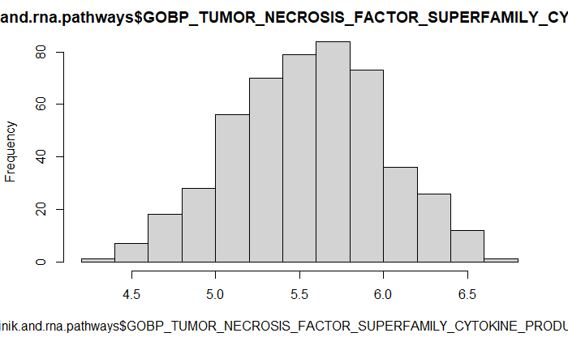

```r
hist(clinik.and.rna.pathways$GOBP_TUMOR_NECROSIS_FACTOR_SUPERFAMILY_CYTOKINE_PRODUCTION)
```

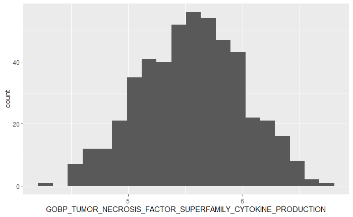

```r
ggplot(clinik.and.rna.pathways, aes(GOBP_TUMOR_NECROSIS_FACTOR_SUPERFAMILY_CYTOKINE_PRODUCTION)) + geom_histogram(bins=20)
```

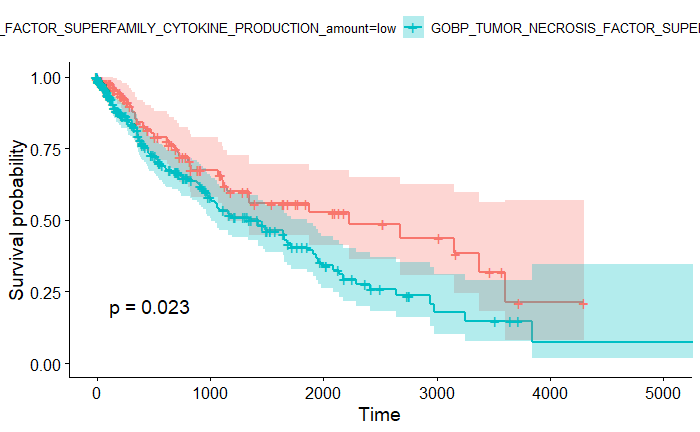

```r
clinik.and.rna.pathways$GOBP_TUMOR_NECROSIS_FACTOR_SUPERFAMILY_CYTOKINE_PRODUCTION_amount <-
  cut(clinik.and.rna.pathways$GOBP_TUMOR_NECROSIS_FACTOR_SUPERFAMILY_CYTOKINE_PRODUCTION,
      breaks=c(-Inf, 5.3, Inf),
      labels=c("low", "high"))

ggsurvplot(survfit(Surv(times, patient.vital_status)~GOBP_TUMOR_NECROSIS_FACTOR_SUPERFAMILY_CYTOKINE_PRODUCTION_amount,
                   data=clinik.and.rna.pathways), pval=TRUE, conf.int=TRUE)
```

```r
mean(clinik.and.rna.pathways$GOBP_REGULATION_OF_TUMOR_NECROSIS_FACTOR_SUPERFAMILY_CYTOKINE_PRODUCTION)
```

```
[1] 5.553347
```

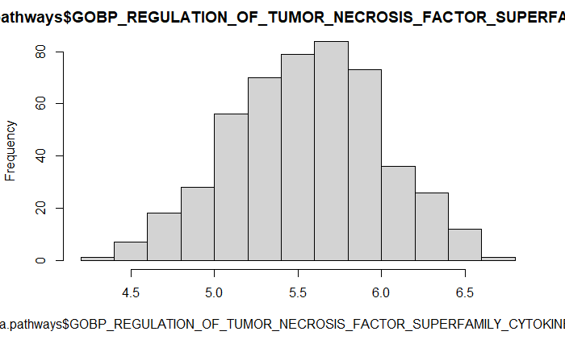

```r
hist(clinik.and.rna.pathways$GOBP_REGULATION_OF_TUMOR_NECROSIS_FACTOR_SUPERFAMILY_CYTOKINE_PRODUCTION)
```

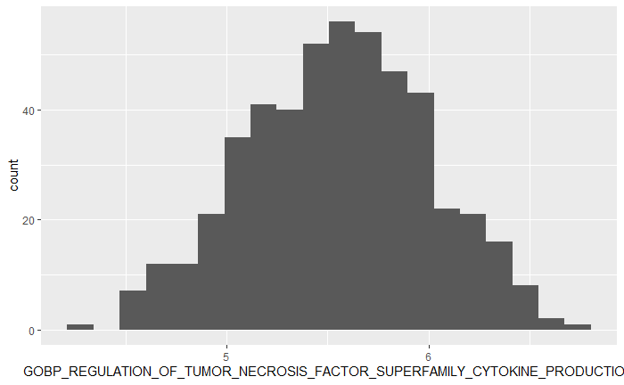

```r
ggplot(clinik.and.rna.pathways, aes(GOBP_REGULATION_OF_TUMOR_NECROSIS_FACTOR_SUPERFAMILY_CYTOKINE_PRODUCTION)) + geom_histogram(bins=20)
```

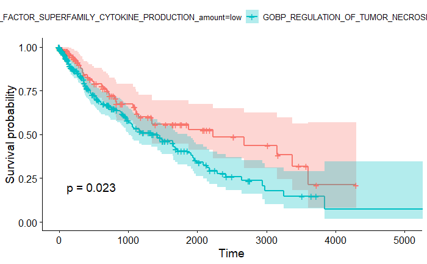

```r
clinik.and.rna.pathways$GOBP_REGULATION_OF_TUMOR_NECROSIS_FACTOR_SUPERFAMILY_CYTOKINE_PRODUCTION_amount <-
  cut(clinik.and.rna.pathways$GOBP_REGULATION_OF_TUMOR_NECROSIS_FACTOR_SUPERFAMILY_CYTOKINE_PRODUCTION,
      breaks=c(-Inf, 5.3, Inf),
      labels=c("low", "high"))

ggsurvplot(survfit(Surv(times, patient.vital_status)~GOBP_REGULATION_OF_TUMOR_NECROSIS_FACTOR_SUPERFAMILY_CYTOKINE_PRODUCTION_amount,
                   data=clinik.and.rna.pathways), pval=TRUE, conf.int=TRUE)
```